# Reproducible Research - Week 1, Assignment 1

Bruce P. L. Johnston

## Loading and Processing The Data

I hope that I will be forgiven the non-generality of this file-reading code. I attempted to use the getwd() command, pasting the working directory to the file name, and so on, but was given an error I have no idea how to correct by RStudio. If anyone knows how to do this and is willing to tell me, let me know.

```r
ActivityData <- read.csv("C:/Users/Admin/Desktop/activity.csv")
```

This data frame will be the primary one used throughout the assignment.

Now we will begin. The first part is

## Calculating the number of steps taken per day and plotting histograms

Since we are allowed to ignore missing values, this part is fairly simple. First compute the number of steps taken per day:

```r
library(plyr, dplyr)
StepSums <- ddply(ActivityData, "date", summarise, Total_Steps = sum(steps, na.rm = TRUE))
```

To make the required histogram, we use

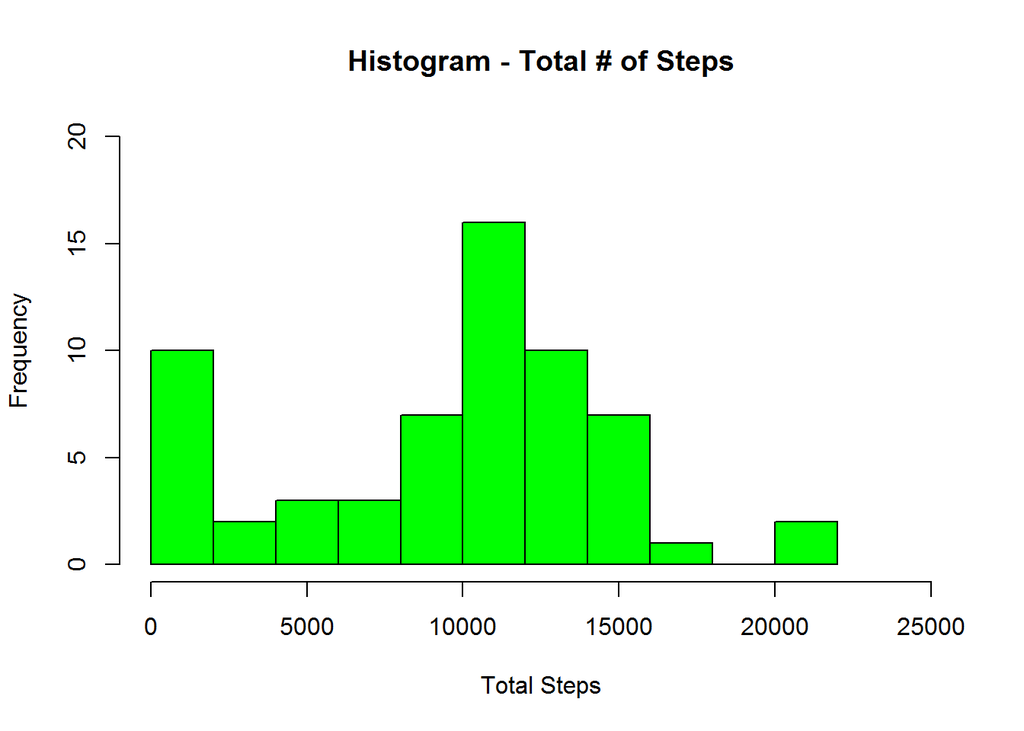

```r
hist(StepSums$Total_Steps, xlim = c(0, 25000),ylim = c(0,20), xlab = "Total Steps", main = "Histogram - Total # of Steps", breaks = 15, col = "green")
```

I apologize in advance for the poor aspect ratio. I have not yet mastered many of the subtleties of R graphics. Any advice on how to do this would be welcome.

Now we compute the mean and median number of steps taken, which is given by

```r
MeanSteps <- mean(StepSums$Total_Steps)
MedianSteps <- median(StepSums$Total_Steps)
MeanSteps
```

```
## [1] 9354.23
```

```r
MedianSteps
```

```
## [1] 10395
```

which are 9354.23 and 10395, respectively.

## Average Daily Activity Pattern

To obtain the plot we need, we first use *ddply* to transform the data, then plot it:

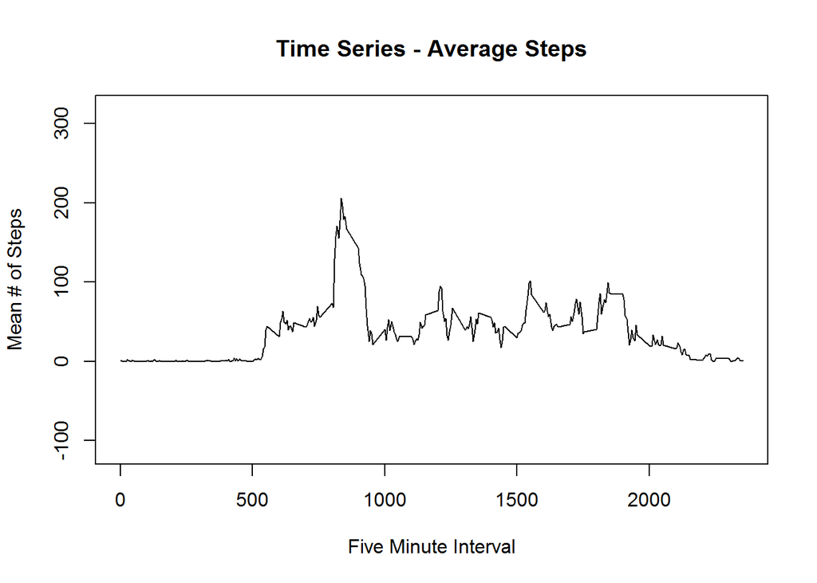

```r
IntervalData <- ddply(ActivityData, "interval", summarise, MeanofSteps = mean(steps, na.rm = TRUE))

plot(IntervalData, type = "l", main = "Time Series - Average Steps", xlab = "Five Minute Interval", ylab = "Mean # of Steps", asp = 3)
```

To find the maximal interval, that is, the one that contains the greatest number of steps on average, type in

```r
V <- subset(IntervalData, MeanofSteps == max(IntervalData$MeanofSteps))

max(V$interval)
```

```
## [1] 835
```

Not terribly elegant, I know. But it does get the job done. If you know of a better way to do this, by all means let me know.

## Missing Values

First we will calculate the total number of rows with NAs in them. A little exploration shows that there are no NAs in the “interval” and “date” columns, so we can concern ourselves with the “steps” column:

```r
V <- is.na(ActivityData)
sum(V[, 2])
```

```
## [1] 0
```

```r
sum(V[, 3])
```

```
## [1] 0
```

```r
sum(V[, 1])
```

```
## [1] 2304
```

Note that we had to use column indices instead of the $ operator, as atomic vectors do not permit the use of that operator. There are 2304 missing values in the dataset.

The strategy I used in replacing the missing values was to use the mean for a given day as the replacement for the missing values. If an entire day contained nothing but NA values, I replaced the mean for that day with zero. I did this using the following code:

```r
Means <- ddply(ActivityData, "date", summarise, MSteps = mean(steps, na.rm= TRUE))

Means$MSteps[Means$MSteps == 'NaN'] <- 0

for (j in 1:nrow(ActivityData)){
  if (is.na(ActivityData$steps[j])){
    for (k in 1:nrow(Means)){
      if (ActivityData$date[j] == Means$date[k]){
        ActivityData$steps[j] <- Means$MSteps[k]
      }
    }
  }
}
```

If we weren’t going to be working with this new dataset for the rest of the assignment, I would have made a copy. To compute the total number of steps taken per day and make a histogram of this data, we use (the mean and median are thrown in for good measure):

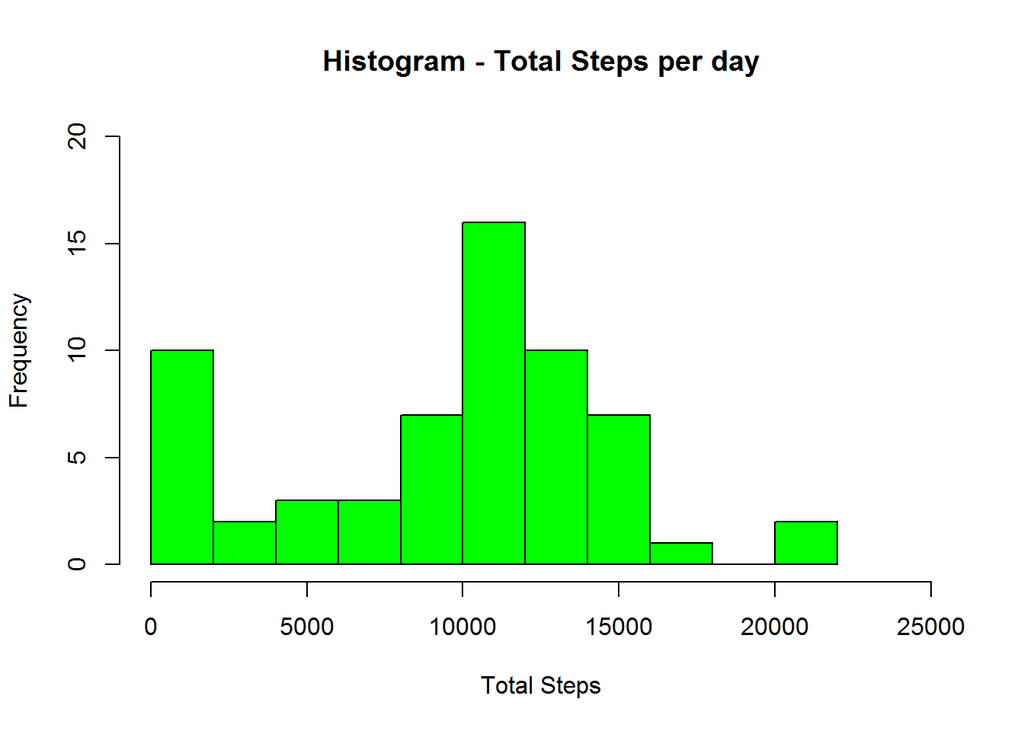

```r
NewTotals <- ddply(ActivityData, "date", summarise, Total_Steps = sum(steps))

hist(NewTotals$Total_Steps, breaks = 12, xlim = c(0,25000), ylim = c(0,20), col = "green", xlab = "Total Steps", main = "Histogram - Total Steps per day")
```

```r
mean(NewTotals$Total_Steps)
```

```
## [1] 9354.23
```

```r
median(NewTotals$Total_Steps)
```

```
## [1] 10395
```

The mean and median are no different from before, nor is the histogram. This means that NA values in the original dataset are concentrated on particular days.

## Exploring weekly patterns

To create the necessary factor variable to categorize weekdays versus weekends, I did the following:

```r
DayofWeek <- weekdays(as.POSIXlt(ActivityData$date))

DayofWeek[(DayofWeek == "Saturday")] <- "Weekend"
DayofWeek[DayofWeek == "Sunday"] <- "Weekend"

DayofWeek[DayofWeek != "Weekend"] <- "Weekday"

ActivityData <- mutate(ActivityData, Type = DayofWeek)
```

To make the plot, we first do the necessary averaging:

```r
Weekends <- subset(ActivityData, Type = "Weekend")
Weekday <- subset(ActivityData, Type = "Weekday")

 WeekendAverage <- ddply(Weekends, "interval", summarise, Average = mean(steps))

WeekdayAverage <- ddply(Weekday, "interval", summarise, Average = mean(steps))

WeekdayAverage <- mutate(WeekdayAverage, Type = "Weekday")
WeekendAverage <- mutate(WeekendAverage, Type = "Weekend")
```

Finally, we will put them back together and make a plot:

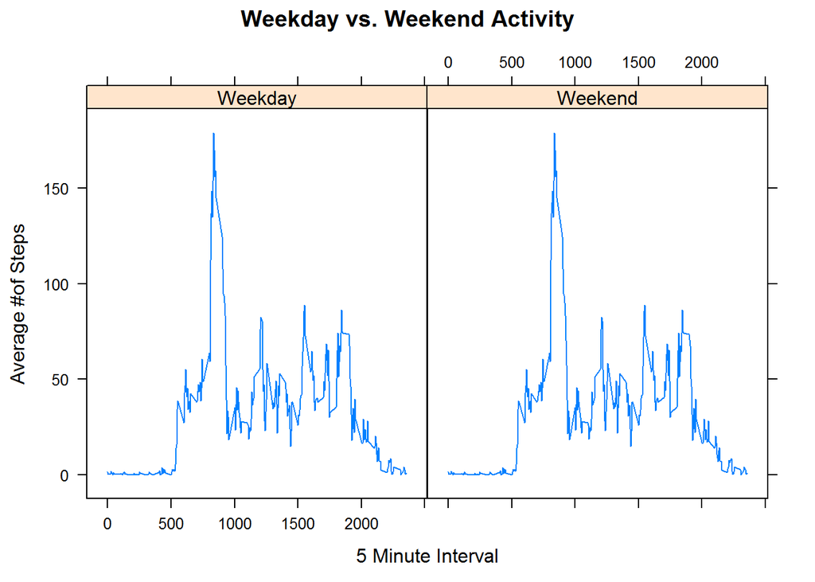

```r
library(lattice)
Big <- rbind(WeekdayAverage, WeekendAverage)

xyplot(Average~interval | factor(Type), data=Big, type = "l", xlab = "5 Minute Interval", ylab = "Average #of Steps", main = "Weekday vs. Weekend Activity")
```

As we can see, not a lot of difference here. In fact, there is so little that I wonder what is going on.